# Automatic vs Manual Transmission Influence on MPG

Mateus Melo

12/10/2020

## Executive Summary

In this analysis, we investigate whether or not there is a significant effect in the type of transmission used (automatic or manual) and the mpg value. This is done performing three steps: an exploratory analysis, where we try to understand the data and observe some trends; a statistical inference, where we try to build strong statistical evidence of the relation between the variables; the build of a regression model that best fits the data. By the end, we interpret our model to see it’s limitations.

## Exploratory Analysis

Let us start by loading and getting some general information about the data.

```r
data("mtcars")
str(mtcars)
```

```
## 'data.frame':    32 obs. of  11 variables:
##  $ mpg : num  21 21 22.8 21.4 18.7 18.1 14.3 24.4 22.8 19.2 ...
##  $ cyl : num  6 6 4 6 8 6 8 4 4 6 ...
##  $ disp: num  160 160 108 258 360 ...
##  $ hp  : num  110 110 93 110 175 105 245 62 95 123 ...
##  $ drat: num  3.9 3.9 3.85 3.08 3.15 2.76 3.21 3.69 3.92 3.92 ...
##  $ wt  : num  2.62 2.88 2.32 3.21 3.44 ...
##  $ qsec: num  16.5 17 18.6 19.4 17 ...
##  $ vs  : num  0 0 1 1 0 1 0 1 1 1 ...
##  $ am  : num  1 1 1 0 0 0 0 0 0 0 ...
##  $ gear: num  4 4 4 3 3 3 3 4 4 4 ...
##  $ carb: num  4 4 1 1 2 1 4 2 2 4 ...
```

We have 32 observations of 11 variables, all of them being of the numeric type. However, checking the [documentation](https://www.rdocumentation.org/packages/datasets/versions/3.6.2/topics/mtcars) of the data, we conclude that the cyl, vs, am gear and carb are categorical variable. Therefore, it will be better to treat them as factors.

```r
mtcars$am<-factor(mtcars$am)
levels(mtcars$am)<-c("Automatic", "Manual")
mtcars$cyl<-factor(mtcars$cyl)
levels(mtcars$cyl)<-c("4cyl", "6cyl", "8cyl")
mtcars$vs<-factor(mtcars$vs)
levels(mtcars$vs)<-c("V-shape", "Straight")
mtcars$gear<-factor(mtcars$gear)
levels(mtcars$vs)<-c("3", "4", "5")
mtcars$carb<-factor(mtcars$carb)
levels(mtcars$carb)<-c("1", "2", "3", "4", "5", "6", "7", "8")
```

We are interested in the mpg relation with the am variable. Let’s try to visualize this with a boxplot.

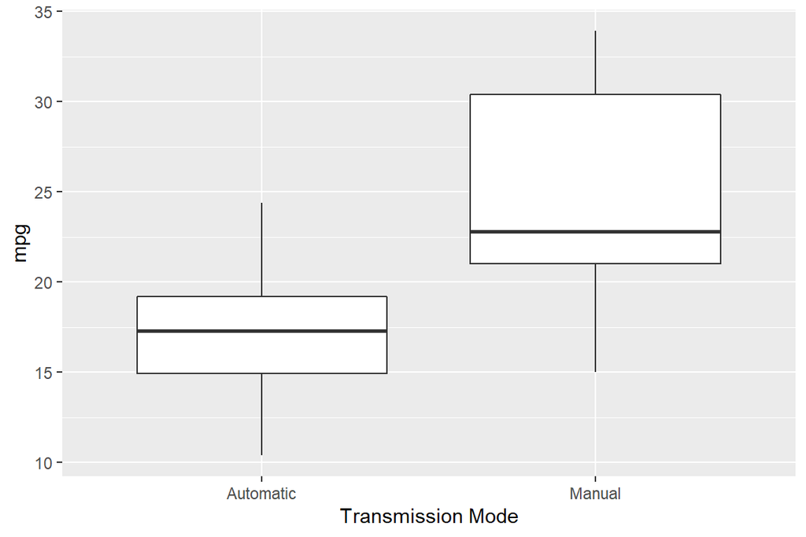

```r
library(ggplot2)
ggplot(mtcars,aes(am,mpg))+geom_boxplot()+xlab("Transmission Mode")
```

There appears to have a difference between using an automatic or manual transmission. Let us see the mpg relation with the rest of the categorical variables.

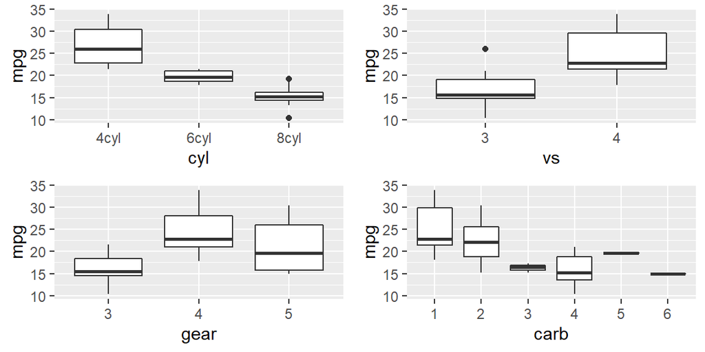

```r
library(gridExtra)
p1 <- ggplot(mtcars, aes(cyl,mpg))+geom_boxplot()
p2 <- ggplot(mtcars, aes(vs,mpg))+geom_boxplot()
p3 <- ggplot(mtcars, aes(gear,mpg))+geom_boxplot()
p4 <- ggplot(mtcars, aes(carb,mpg))+geom_boxplot()
grid.arrange(p1,p2,p3,p4,nrow=2)
```

Mpg seems to be related to the cyl and vs variables.

To finish our exploratory analysis, let’s take a look a the relation between the mpg and the numeric variables.

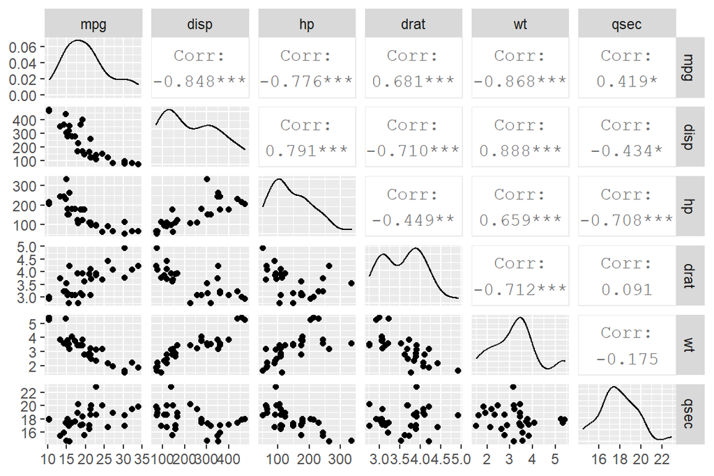

```r
library(GGally)
ggpairs(mtcars,columns = c(1,3,4,5,6,7))
```

We have seen that the mpg variable is strongly correlated with all the numeric variables with the exception of qsec.

## Statistical Inference

To see if the am, vs and cyl variables actually affects the mpg, we are going to perform a t test. As we have seen, the data is not paired and the variance is different.

```r
am_p.value <- t.test(mpg~am, data=mtcars)$p.value
vs_p.value <- t.test(mpg~vs, data=mtcars)$p.value
cyl_4_6_p.value <- t.test(mpg~cyl,data=subset(mtcars,cyl=="4cyl" | cyl=="6cyl"))$p.value
cyl_6_8_p.value <- t.test(mpg~cyl,data=subset(mtcars,cyl=="8cyl" | cyl=="6cyl"))$p.value
cbind(am_p.value,vs_p.value,cyl_4_6_p.value,cyl_6_8_p.value)
```

```
##       am_p.value   vs_p.value cyl_4_6_p.value cyl_6_8_p.value
## [1,] 0.001373638 0.0001098368    0.0004048495    4.540355e-05
```

Since all the tests returned very low p values (all of them being below 0.01), we can assume that these variables indeed affect the mpg.

## Regression Model

We are going to start to build our model including all the variables which we considered relevant in the steps above and see how well it fits the data.

```r
df <- subset(mtcars, select=c("mpg", "am", "cyl","vs","disp", "hp", "drat", "wt" ))
fit1 <- lm(mpg~.,df)
summary(fit1)$coef
```

```
##                 Estimate Std. Error      t value     Pr(>|t|)
## (Intercept) 29.829969134 6.74446788  4.422879559 0.0001962074
## amManual     2.558988828 1.74302127  1.468134026 0.1556117761
## cyl6cyl     -2.055523435 1.80310789 -1.139989150 0.2660238246
## cyl8cyl     -0.023304443 3.81651017 -0.006106218 0.9951806281
## vs4          2.004897600 1.82994849  1.095603300 0.2845926673
## disp         0.004360163 0.01303611  0.334468226 0.7410571328
## hp          -0.035794756 0.01463423 -2.445960216 0.0225138202
## drat         0.388141033 1.46606024  0.264751080 0.7935593982
## wt          -2.594622674 1.20129538 -2.159854031 0.0414485707
```

```r
library(car)
vif(fit1)
```

```
##           GVIF Df GVIF^(1/(2*Df))
## am    3.780870  1        1.944446
## cyl  17.119704  2        2.034108
## vs    4.251750  1        2.061977
## disp 13.047000  1        3.612063
## hp    5.031751  1        2.243156
## drat  3.071076  1        1.752449
## wt    6.905333  1        2.627800
```

```r
fit2 <- lm(mpg~am+vs, df)
fit3 <- lm(mpg~am+vs+wt, df)
fit4 <- lm(mpg~am+vs+wt+hp, df)
fit5 <- lm(mpg~am+vs+disp+hp+wt, df)
fit6 <- lm(mpg~am+vs+cyl+disp+hp+wt, df)
fit7 <- lm(mpg~am+vs+cyl+disp+hp+wt+drat, df)
anova(fit2,fit3,fit4,fit5,fit6,fit7)
```

|  | Res.Df | RSS | Df | Sum of Sq | F | Pr(>F) |
| --- | --- | --- | --- | --- | --- | --- |
| 1 | 29 | 353.4860 | NA | NA | NA | NA |
| 2 | 28 | 216.3157 | 1 | 137.1702247 | 22.11562774 | 9.765246e-05 |
| 3 | 27 | 168.9635 | 1 | 47.3522105 | 7.63448381 | 1.106886e-02 |
| 4 | 26 | 164.3111 | 1 | 4.6524315 | 0.75010043 | 3.953895e-01 |
| 5 | 24 | 143.0902 | 2 | 21.2208737 | 1.71069540 | 2.029457e-01 |
| 6 | 23 | 142.6555 | 1 | 0.4347465 | 0.07009313 | 7.935594e-01 |

Including wt and hp in our model provokes significant changes in the variance. Therefore, we can assume that fit4 can serve as a valid model.

## Model Interpreting

Let us check some general information of the chosen model.

```r
summary(fit4)
```

```
##
## Call:
## lm(formula = mpg ~ am + vs + wt + hp, data = df)
##
## Residuals:
##     Min      1Q  Median      3Q     Max
## -3.6710 -1.7876 -0.3044  1.2895  5.3296
##
## Coefficients:
##             Estimate Std. Error t value Pr(>|t|)
## (Intercept) 31.07879    3.39277   9.160    9e-10 ***
## amManual     2.41714    1.37938   1.752   0.0911 .
## vs4          1.78555    1.32714   1.345   0.1897
## wt          -2.59100    0.91740  -2.824   0.0088 **
## hp          -0.03010    0.01094  -2.751   0.0105 *
## ---
## Signif. codes:  0 '***' 0.001 '**' 0.01 '*' 0.05 '.' 0.1 ' ' 1
##
## Residual standard error: 2.502 on 27 degrees of freedom
## Multiple R-squared:  0.8499, Adjusted R-squared:  0.8277
## F-statistic: 38.23 on 4 and 27 DF,  p-value: 9.445e-11
```

To end up, let us see the residuals behavior against the fitted values.

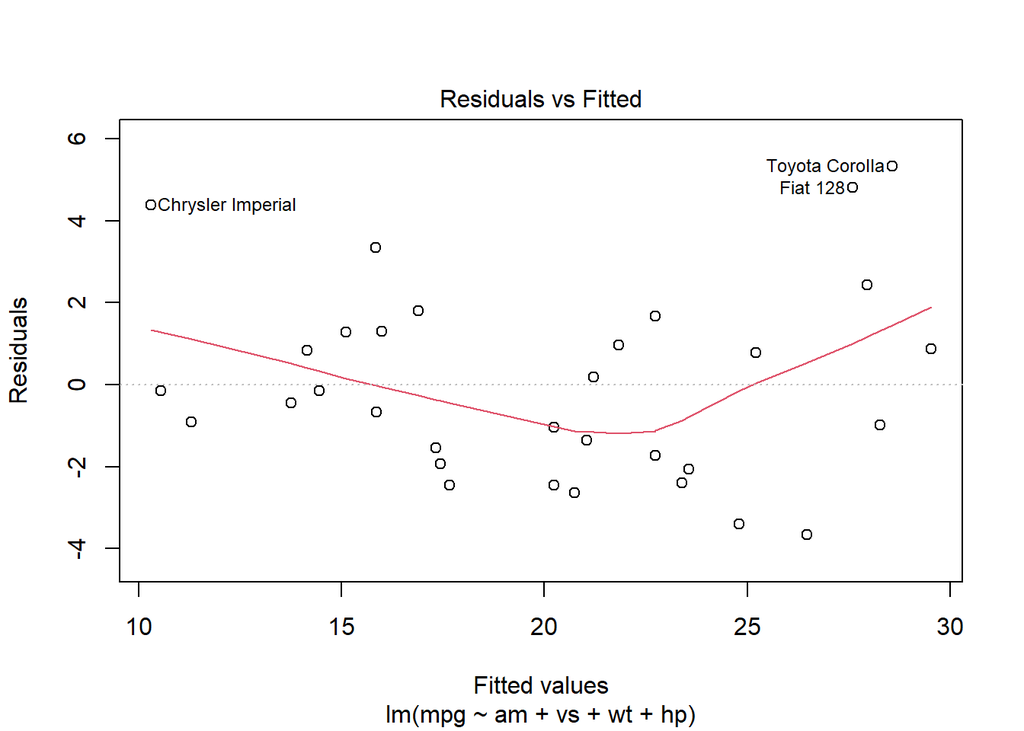

```r
plot(fit4,which=1)
```

## Conclusion

Although there is a difference in the mpg when we change from automatic to manual transmission (the change is around 2.42), we lack of strong statistical evidence to conclude that the manual transmission is indeed better than the automatic one.